# DA5020.A9.Nithya.Sarabudla

nithyasarabudla

2023-11-18

```r
library(dplyr)
```

```r
library(ggplot2)
library(lubridate)
library(rvest)
library(RSocrata)
```

# Question 1

```r
# loading the data
air_traffic_passenger_stats <- read.socrata("https://data.sfgov.org/Transportation/Air-Traffic-Passenger-Statistics/rkru-6vcg")

str(air_traffic_passenger_stats)
```

```
## 'data.frame':    34734 obs. of  15 variables:
##  $ activity_period            : int  199907 199907 199907 199907 199907 199907 199907 199907 199907 199907 ...
##  $ activity_period_start_date : POSIXct, format: "1999-07-01" "1999-07-01" ...
##  $ operating_airline          : chr  "ATA Airlines" "ATA Airlines" "ATA Airlines" "Aeroflot Russian International Airlines" ...
##  $ operating_airline_iata_code: chr  "TZ" "TZ" "TZ" "" ...
##  $ published_airline          : chr  "ATA Airlines" "ATA Airlines" "ATA Airlines" "Aeroflot Russian International Airlines" ...
##  $ published_airline_iata_code: chr  "TZ" "TZ" "TZ" "" ...
##  $ geo_summary                : chr  "Domestic" "Domestic" "Domestic" "International" ...
##  $ geo_region                 : chr  "US" "US" "US" "Europe" ...
##  $ activity_type_code         : chr  "Deplaned" "Enplaned" "Thru / Transit" "Deplaned" ...
##  $ price_category_code        : chr  "Low Fare" "Low Fare" "Low Fare" "Other" ...
##  $ terminal                   : chr  "Terminal 1" "Terminal 1" "Terminal 1" "Terminal 2" ...
##  $ boarding_area              : chr  "B" "B" "B" "D" ...
##  $ passenger_count            : int  31432 31353 2518 1324 1198 24124 23613 4983 4604 205 ...
##  $ data_as_of                 : POSIXct, format: "2023-10-20 15:06:37" "2023-10-20 15:06:37" ...
##  $ data_loaded_at             : POSIXct, format: "2023-10-20 15:08:13" "2023-10-20 15:08:13" ...
```

# Question 2

```r
# Convert relevant columns to numeric data types for analysis
air_traffic_passenger_stats$activity_period <- as.numeric(air_traffic_passenger_stats$activity_period)
air_traffic_passenger_stats$passenger_count <- as.numeric(air_traffic_passenger_stats$passenger_count)

# Filter the dataset to include only domestic passenger activity in March
domestic_march_data <- air_traffic_passenger_stats %>%
  filter(geo_summary == "Domestic" & format(activity_period_start_date, "%m") == "03")

# Create the 'year' column from 'activity_period'
domestic_march_data <- domestic_march_data %>%
  mutate(year = floor(activity_period / 100))  # Assuming 'activity_period' is in YYYYMM format

# Aggregate the data to calculate the total passengers for each year
total_domestic_passengers <- domestic_march_data %>%
  group_by(activity_period, year) %>%
 summarise(total_passengers = sum(passenger_count, na.rm = TRUE))
```

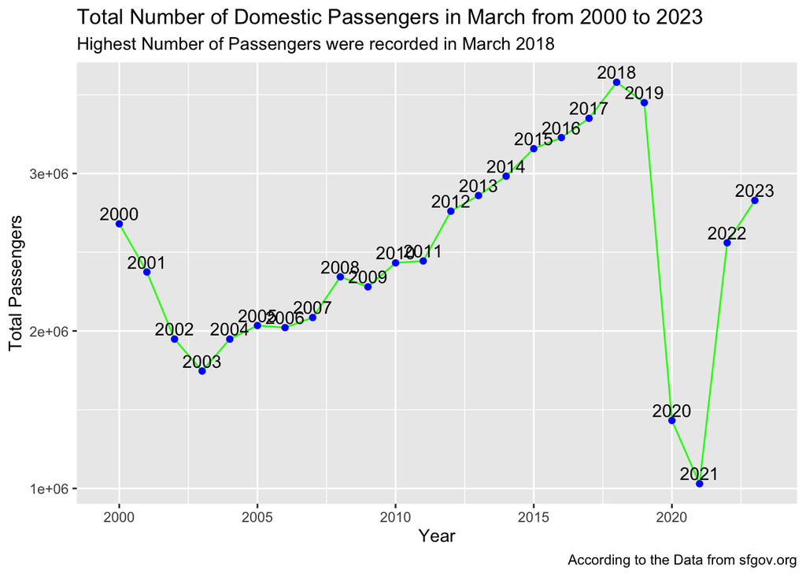

```r
# Create the plot
ggplot(total_domestic_passengers, aes(x = year, y = total_passengers)) +
  geom_line(color = "green") +
  geom_point(color = "blue") +
  geom_text(aes(label = year), position = position_dodge(width = 0.7),
           vjust = -0.3) +
  labs(title = "Total Number of Domestic Passengers in March from 2000 to 2023",
       subtitle = "Highest Number of Passengers were recorded in March 2018",
       x = "Year", y = "Total Passengers",
       caption = "According to the Data from sfgov.org")
```

In the graph Total Number of Domestic passengers in march from 2000 to 2023, Highest number of passengers were recorded in march 2018 and least number of passengers are recorded in 2021, there is increase in passengers from 2003 to 2018 and got major decline in 2020 and 2021.

# Question 3

```r
# Select data for specific time periods (201603, 201703, 201803) for simple moving average
simple_moving_average_data <- total_domestic_passengers %>%
  filter(activity_period %in% c(201603, 201703, 201803)) %>%
  select(activity_period, total_passengers)

# Compute the mean of the total passengers from selected time periods for simple moving average
simple_moving_average <- mean(simple_moving_average_data$total_passengers)

# Forecast the total passenger count for March 2019 for simple moving average
forecasted_value_sma <- simple_moving_average

# Extract the actual total passengers for March 2019 for simple moving average
actual_value_sma <- total_domestic_passengers %>%
  filter(activity_period == 201903) %>%
  pull(total_passengers)

# Calculate the error for simple moving average
error_sma <- actual_value_sma - forecasted_value_sma

# Print the results for simple moving average
cat("Forecasted Value for March 2019 (SMA):", forecasted_value_sma, "\n")
```

```
## Forecasted Value for March 2019 (SMA): 3385803
```

```r
cat("Actual Value for March 2019 (SMA):", actual_value_sma, "\n")
```

```
## Actual Value for March 2019 (SMA): 3449863
```

```r
cat("Error (SMA):", error_sma, "\n")
```

```
## Error (SMA): 64059.67
```

This positive error indicates that the SMA underestimated the total passenger count for March 2019. The actual value is higher than the forecasted value by approximately 64,059.67.

# Question 4

```r
# Define weights for the three-year weighted moving average
weights <- c(3, 5, 7)

# Select data for specific time periods (201603, 201703, 201803) for weighted moving average
weighted_moving_average_data <- total_domestic_passengers %>%
  filter(activity_period %in% c(201603, 201703, 201803)) %>%
  select(activity_period, total_passengers)

# Compute the weighted moving average for total passenger count
weighted_moving_average <- sum(weighted_moving_average_data$total_passengers * weights) / sum(weights)

# Forecast the total passenger count for March 2019 for weighted moving average
forecasted_value_wma <- weighted_moving_average

# Calculate the error for weighted moving average
error_wma <- actual_value_sma - forecasted_value_wma

# Print the results for the weighted moving average
cat("Weighted Moving Average Forecast for March 2019 (WMA):", forecasted_value_wma, "\n")
```

```
## Weighted Moving Average Forecast for March 2019 (WMA): 3432674
```

```r
cat("Actual Value for March 2019 (WMA):", actual_value_sma, "\n")
```

```
## Actual Value for March 2019 (WMA): 3449863
```

```r
cat("Error (WMA):", error_wma, "\n")
```

```
## Error (WMA): 17188.73
```

This positive error indicates that the WMA slightly underestimated the total passenger count for March 2019. The actual value is higher than the forecasted value by approximately 17,188.73.

# Question 5

```r
# Filter data for training the exponential smoothing model
training_data_es <- total_domestic_passengers %>%
  filter(activity_period >= 200803 & activity_period <= 201803) %>%
  select(activity_period, total_passengers)

# Initialize forecast and smoothing parameter
forecast <- training_data_es$total_passengers[1]
alpha <- 0.7

# Update forecast and smoothing parameter for each observation
for (i in 2:length(training_data_es$total_passengers)) {
  actual <- training_data_es$total_passengers[i]
  forecast <- alpha * actual + (1 - alpha) * forecast
}

# Forecast the total passenger count for March 2019
forecasted_value_es <- forecast

# Extract the actual total passengers for March 2019
actual_value_es <- total_domestic_passengers %>%
  filter(activity_period == 201903) %>%
  pull(total_passengers)

# Calculate the error for exponential smoothing
error_es <- actual_value_es - forecasted_value_es

# Print the results for exponential smoothing
cat("Forecasted Value for March 2019 (Exponential Smoothing):", forecasted_value_es, "\n")
```

```
## Forecasted Value for March 2019 (Exponential Smoothing): 3495868
```

```r
cat("Actual Value for March 2019:", actual_value_es, "\n")
```

```
## Actual Value for March 2019: 3449863
```

```r
cat("Error (Exponential Smoothing):", error_es, "\n")
```

```
## Error (Exponential Smoothing): -46005.37
```

The Exponential Smoothing model with alpha set to 0.7 forecasted a total passenger count of 3,495,868 for March 2019, exceeding the actual value of 3,449,863 by 46,005.37. The negative error indicates an overestimation by the model, suggesting a potential sensitivity to recent observations and a need for further tuning.

# Question 6

```r
# Filter the dataset for the time period from 2008 to 2018
data <- total_domestic_passengers %>%
  filter(activity_period >= 200803 & activity_period <= 201803) %>%
  select(activity_period, total_passengers)

# Fit a simple linear regression model
linear_regression_model <- lm(total_passengers ~ activity_period, data = data)

# Extract the coefficients
intercept <- coef(linear_regression_model)[1]
slope <- coef(linear_regression_model)[2]

# Function to make predictions using the coefficients
predict_passengers <- function(year) {
  return(intercept + slope * year)
}

# Make predictions for 2019 and 2020
prediction_2019 <- predict_passengers(201903)
prediction_2020 <- predict_passengers(202003)

# Print the results
cat("Forecasted Value for 2019 (Linear Regression):", prediction_2019, "\n")
```

```
## Forecasted Value for 2019 (Linear Regression): 3646905
```

```r
cat("Forecasted Value for 2020 (Linear Regression):", prediction_2020, "\n")
```

```
## Forecasted Value for 2020 (Linear Regression): 3778674
```

The linear regression model predicts an increasing trend in total passenger activity based on historical data from 2008 to 2018. The forecasted values for 2019 and 2020 are 3,646,905 and 3,778,674, respectively.

# Question 7

```r
# Question 5 - Exponential Smoothing Model
# Filter data for training the exponential smoothing model
training_data_es <- total_domestic_passengers %>%
  filter(activity_period >= 200803 & activity_period <= 201803) %>%
  select(activity_period, total_passengers)

# Initialize forecast and smoothing parameter
forecast <- training_data_es$total_passengers[1]
alpha <- 0.7

# Initialize squared errors for exponential smoothing
squared_errors_es <- numeric(length = nrow(training_data_es))

# Update forecast and smoothing parameter for each observation
for (i in 2:length(training_data_es$total_passengers)) {
  actual <- training_data_es$total_passengers[i]
  forecast <- alpha * actual + (1 - alpha) * forecast
  squared_errors_es[i] <- (actual - forecast)^2
}

# Calculate MSE for Exponential Smoothing
mse_es <- mean(squared_errors_es)

# Print the MSE for Exponential Smoothing
cat("Mean Squared Error (Exponential Smoothing):", mse_es, "\n")
```

```
## Mean Squared Error (Exponential Smoothing): 3141864472
```

```r
# Question 6 - Linear Regression Model
# Filter the dataset for the time period from 2008 to 2018
data_lr <- total_domestic_passengers %>%
  filter(activity_period >= 200803 & activity_period <= 201803) %>%
  select(activity_period, total_passengers)

# Fit a simple linear regression model
linear_regression_model <- lm(total_passengers ~ activity_period, data = data_lr)

# Extract the coefficients
intercept_lr <- coef(linear_regression_model)[1]
slope_lr <- coef(linear_regression_model)[2]

# Function to make predictions using the coefficients
predict_passengers_lr <- function(year) {
  return(intercept_lr + slope_lr * year)
}

# Initialize squared errors for linear regression
squared_errors_lr <- numeric(length = nrow(data_lr))

# Make predictions for each observation and calculate squared errors
for (i in 1:nrow(data_lr)) {
  actual <- data_lr$total_passengers[i]
  prediction <- predict_passengers_lr(data_lr$activity_period[i])
  squared_errors_lr[i] <- (actual - prediction)^2
}

# Calculate MSE for Linear Regression
mse_lr <- mean(squared_errors_lr)

# Print the MSE for Linear Regression
cat("Mean Squared Error (Linear Regression):", mse_lr, "\n")
```

```
## Mean Squared Error (Linear Regression): 5017266497
```

```r
# Question 7 - Compare MSE
# Compare and comment on which model has the smallest MSE
if (mse_es < mse_lr) {
  cat("Exponential Smoothing Model has the smallest Mean Squared Error.\n")
} else if (mse_lr < mse_es) {
  cat("Linear Regression Model has the smallest Mean Squared Error.\n")
} else {
  cat("Both models have the same Mean Squared Error.\n")
}
```

```
## Exponential Smoothing Model has the smallest Mean Squared Error.
```

The Exponential Smoothing model, with an alpha of 0.7, has a Mean Squared Error (MSE) of 3,141,864,472, while the Linear Regression model has an MSE of 5,017,266,497. The Exponential Smoothing model outperforms the Linear Regression model in terms of forecasting accuracy, as it has a smaller MSE. This suggests that, based on the given data from 2008 to 2018, the Exponential Smoothing model provides a more accurate prediction of total passenger activity.